# Projekt

Author

Michał Kozioł

# Wstęp

Powiązania między warunkami pogodowymi a ilością oraz jakością zbiorów tymianku.

Fajsławice to polskie zagłębie ziól, znajomość korelacji między pogodą a spodziewanymi zbiorami byłoby korzystne dla rolników i hurtowni.

# Pytania badawcze i hipotezy

**Pytanie 1**: Jak wilgotność w pogodzie wpływa na jakość i ilość tymianku?

- **Hipoteza 1.1**: Stan wody w najbliższej mierzonej rzece nie ma istotnego wpływu na uprawę tymianku.
- **Hipoteza 1.2**: Średnia wilgotność ma istotny wpływ na wilgoć mierzoną w tymianku oraz jego jakość.
- **Hipoteza 1.3**: Opady w miesiącach zbiorów tymianku negatywnie wpływają na jego jakość.
- **Hipoteza 1.4**: Opady w miesiącach wzrostu tymianku pozytywnie wpływają na jego ilość.

**Pytanie 2**: Jak sytuacja przy gruncie wpływa na jakość i ilość tymianku?

- **Hipoteza 2.1**: Minimalna temperatura gruntu w miesiącach wzrostu tymianku ma wpływ na jego ilość w okresie zbiorów.
- **Hipoteza 2.2**: Ilość dni z zaobserwowaną rosą w miesiącach wzrostu tymianku ma wpływ na jego ilość w okresie zbiorów.

**Pytanie 3**: Jak warunki atmosferyczne wpływają na jakość i ilość tymianku?

- **Hipoteza 3.1**: Duże nasłonecznienie w miesiącach zbiorów tymianku pozytywnie wpływają na jego jakość.
- **Hipoteza 3.2**: Duże nasłonecznienie w miesiącach siania tymianku negatywnie wpływają na jego ilość podczas zbiorów.
- **Hipoteza 3.3**: Ciśnienie atmosferyczne nie wpływa znacznie na uprawy tymianku.
- **Hipoteza 3.4**: Prędkość wiatru nie wpływa znacznie na uprawy tymianku.

# Eksploracja zbioru danych

## Dane Zielarskie

Dane dotyczące zbiorów tymianku zostały podarowane przez firmę prowadzącą skup od lokalnych rolników.

Podstawowe dane zielarskie zawierają datę przyjęcia ziół w hurtowni, ich wagę, wilgoć oraz stężenie olejków eterycznych. Olejki eteryczne są główną miarą jego jakości.

| Średnia waga | Średnie olejki | Średnia wilgoć |
| --- | --- | --- |
| 2896 | 2.21 | 6.27 |

Do każdego rekordu jest także przypisany sezon. Tymianek sieje się w okolicach kwietnia a zbiera od połowy września do października/listopoada. Główny skup trwa od września do czerwca.

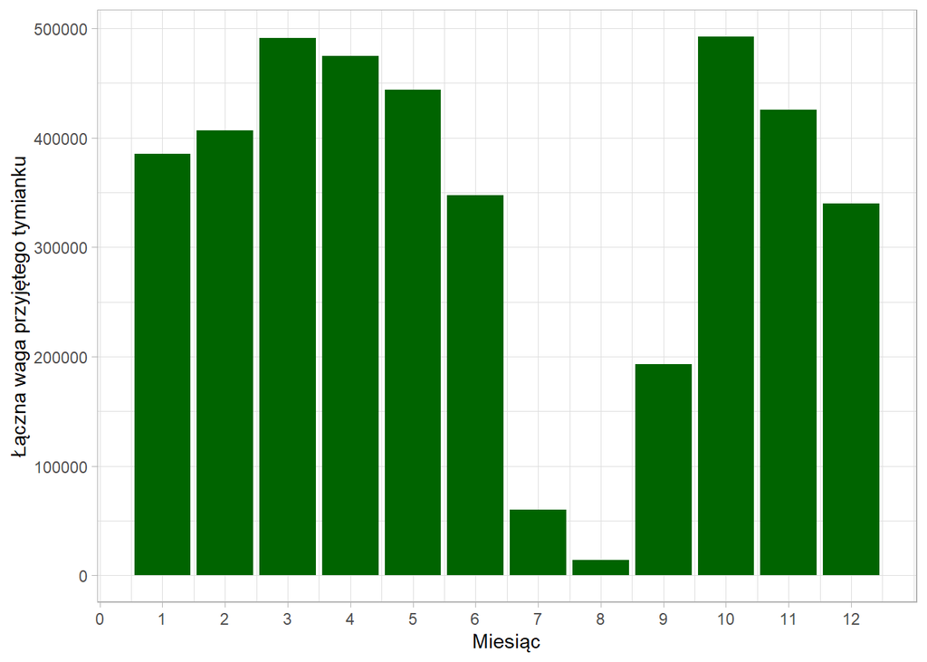

W lipcu i sierpniu skupuje się o wiele mniej towaru, dlatego te miesiące nie będą uwzględniane. Szczegółowe, użyteczne dane zbierane są dopiero od połowy 2019 roku, więc nie będzie brany pod uwagę sezon 2018. Luki w informacjach o wartości olejków oraz wilgoci zostały wypełnione średnią wartością (2.2057 dla oleju i 6.2719 dla wilgoci).

**Waga a Olej**

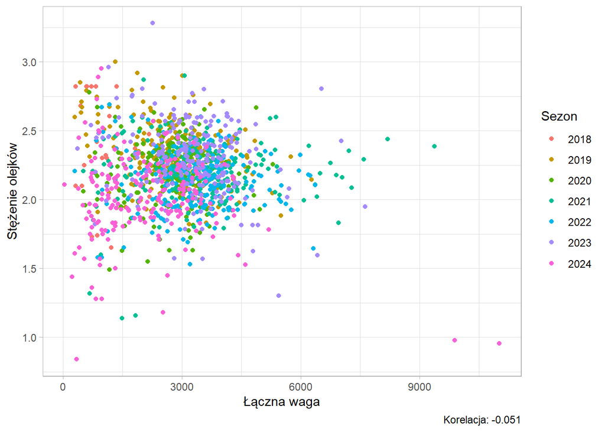

**Waga a Wilgoć**

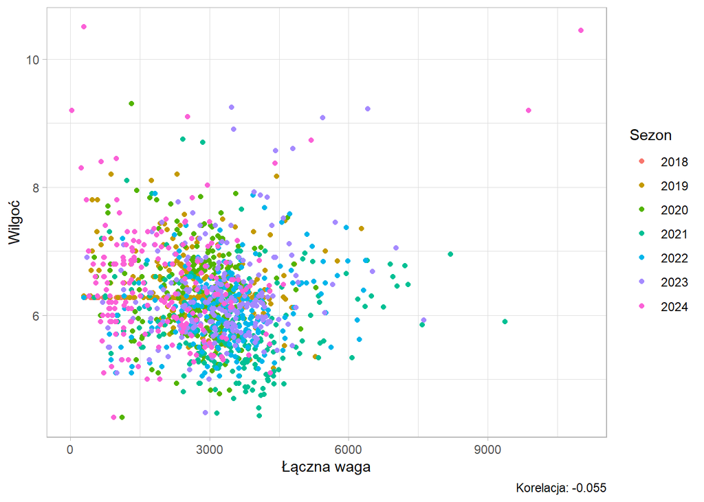

**Wilgoć a Olej**

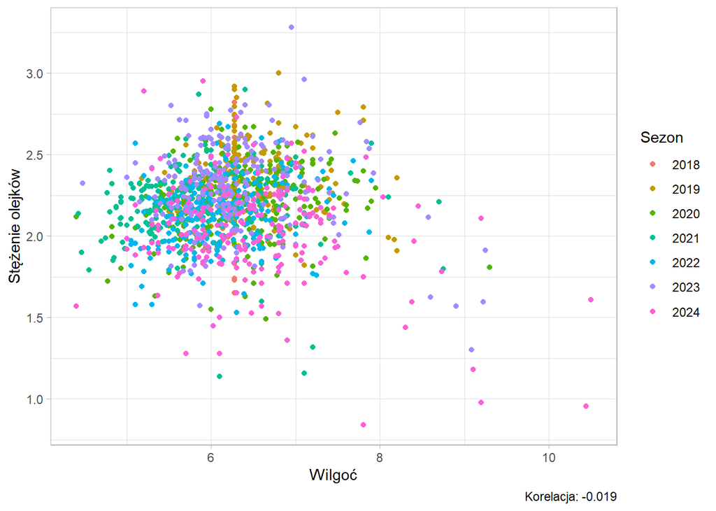

## Dane Metorologiczne

Dane pogodowe zostały zebrane z publicznych archiwów IMGW.

W bezpośredniej okolicy uprawianego tymianku nie ma zbieranych danych pogodowych, więc zostały one zagregowane z kilku lokacji w woj. lubelskim.

Pewne szczegółowe dane pogodowe, takie jak suma dni z zaobserwowaną rosą albo stan wody w najbliższej istotnej rzece kończą się na początku 2024 roku. Te bardziej ogólne, takie jak średnia temperatura czy ciśnienie atmosferyczne kończą się w połowie 2024.

## Zakres Zbiorów

Limitacje zbiorów metorologicznych oraz zielarskich oznaczają, że analizie poddane będą sezony uprawy 2019 - 2023 (czyli od września 2019 do czerwca 2024)

# Pytanie 1

“Jak wilgotność w pogodzie wpływa na jakość i ilość tymianku?”

## Odpowiedź na hipotezę 1.1

“Stan wody w najbliższej mierzonej rzece nie ma istotnego wpływu na uprawę tymianku”

**Stan wody a olejki**

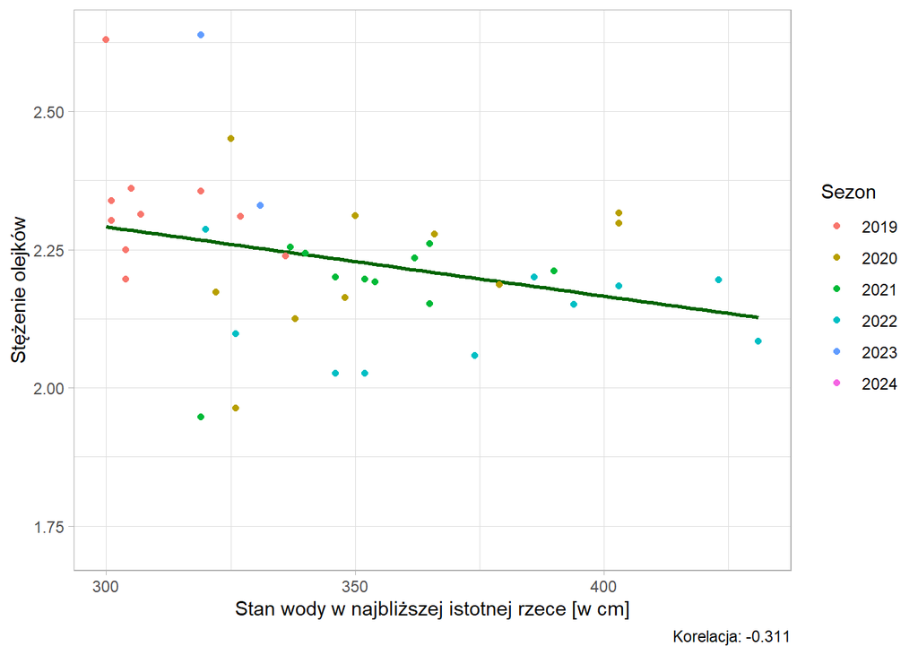

**Stan wody a wilgotność**

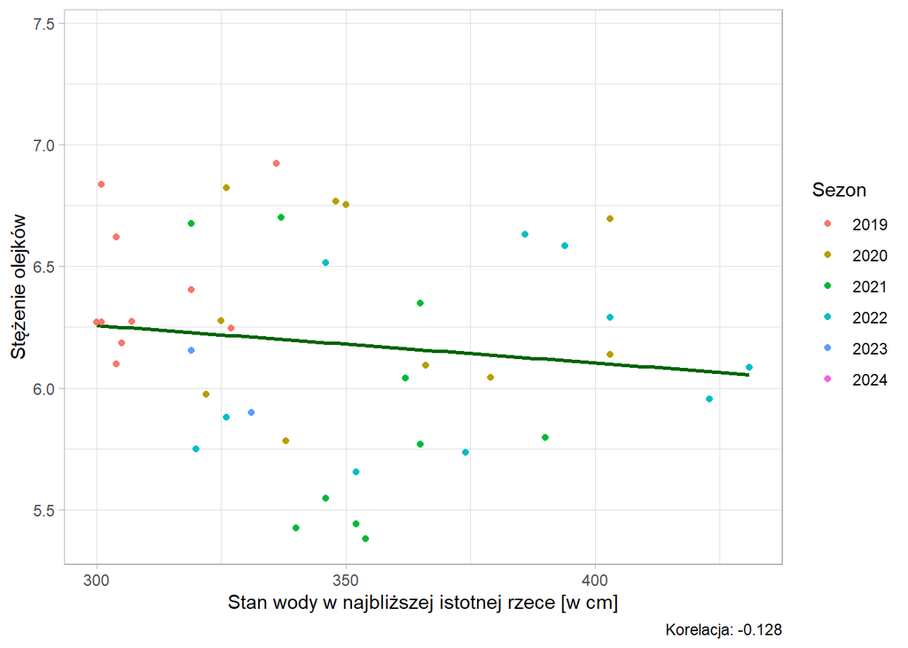

O dziwo istnieje pewna negatywna korelacja między stanem wody a olejkami. Najprawdopodobniej nie jest to jednak bezpośredni wpływ rzeki a efekt opadó (które będą sprawdzane w hipotezie 1.3).

## Odpowiedź na hipotezę 1.2

“Średnia wilgotność ma istotny wpływ na wilgoć mierzoną w tymianku oraz jego jakość”

**Wilgotność a wilgoć**

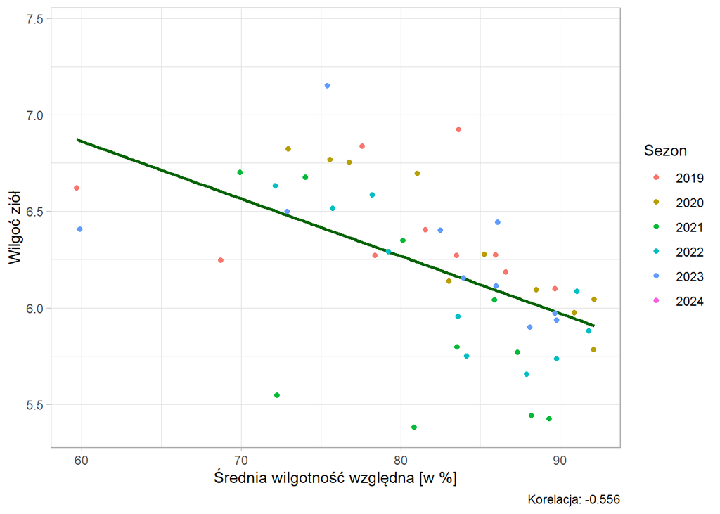

**Wilgotność a olejki**

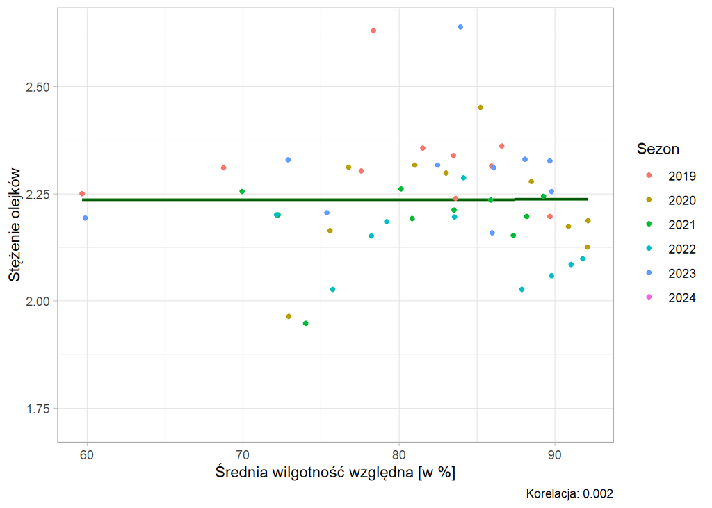

Zaskakująco, jest duża korelacja między wysoką wilgotnością a suchymi ziołami.

Odpowiedź kryje się w charakterze badanych danych. Wilgoć w ziołach mierzona jest po suszeniu. Im większa wilgotność względna wymaga dużo większego suszenia więc produkuje także suchsze zioła.

## Odpowiedź na hipotezę 1.3

“Opady w miesiącach zbiorów tymianku negatywnie wpływają na jego jakość”

**Suma opadów**

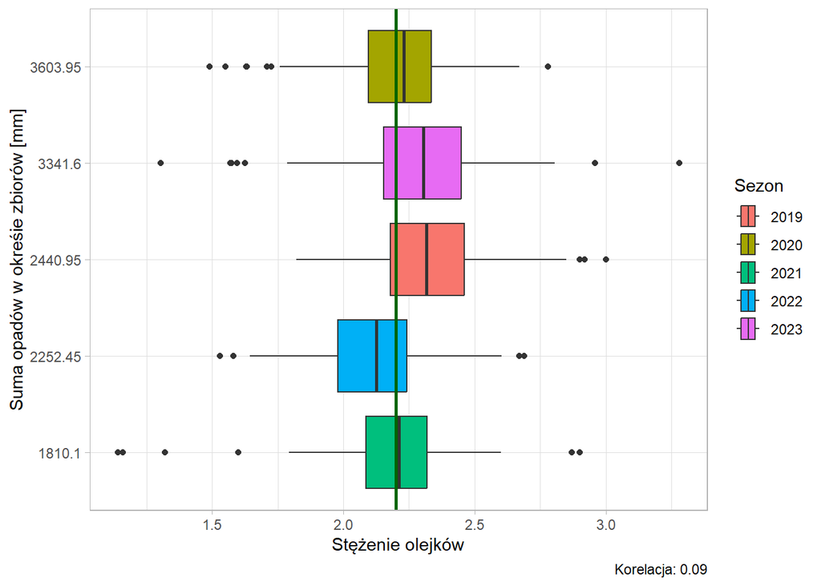

**Maksymalna dobowa suma opadów**

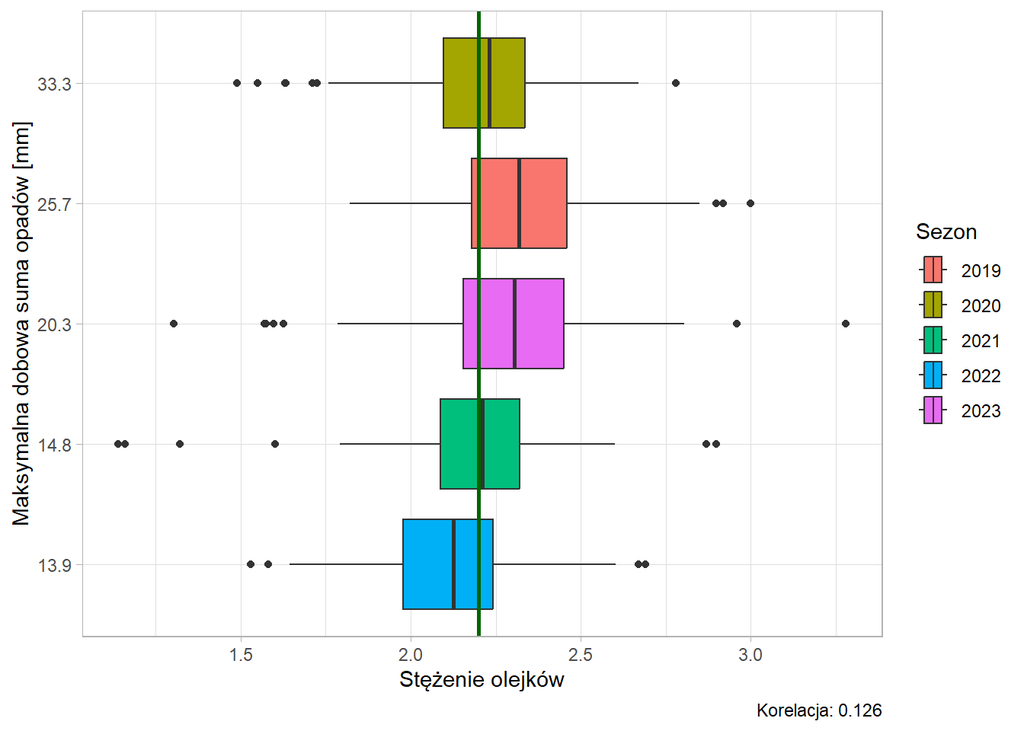

**Średnia suma opadów w dzień**

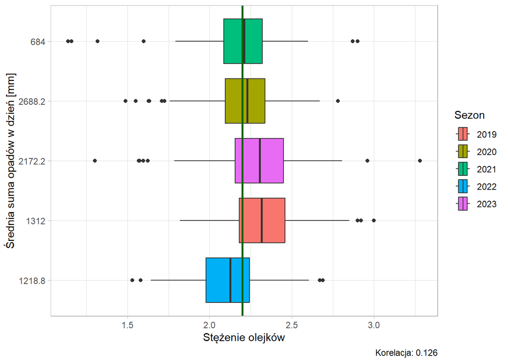

**Średnia suma opadów w noc**

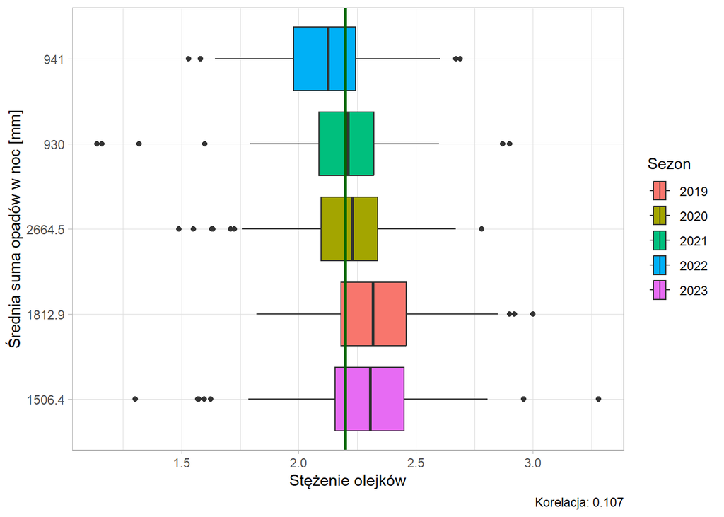

**Dni z deszczem**

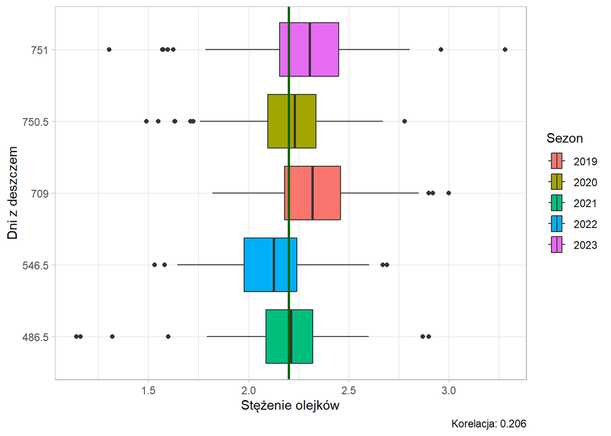

## Odpowiedź na hipotezę 1.4

“Opady w miesiącach wzrostu tymianku pozytywnie wpływają na jego ilość”

**Suma opadów**

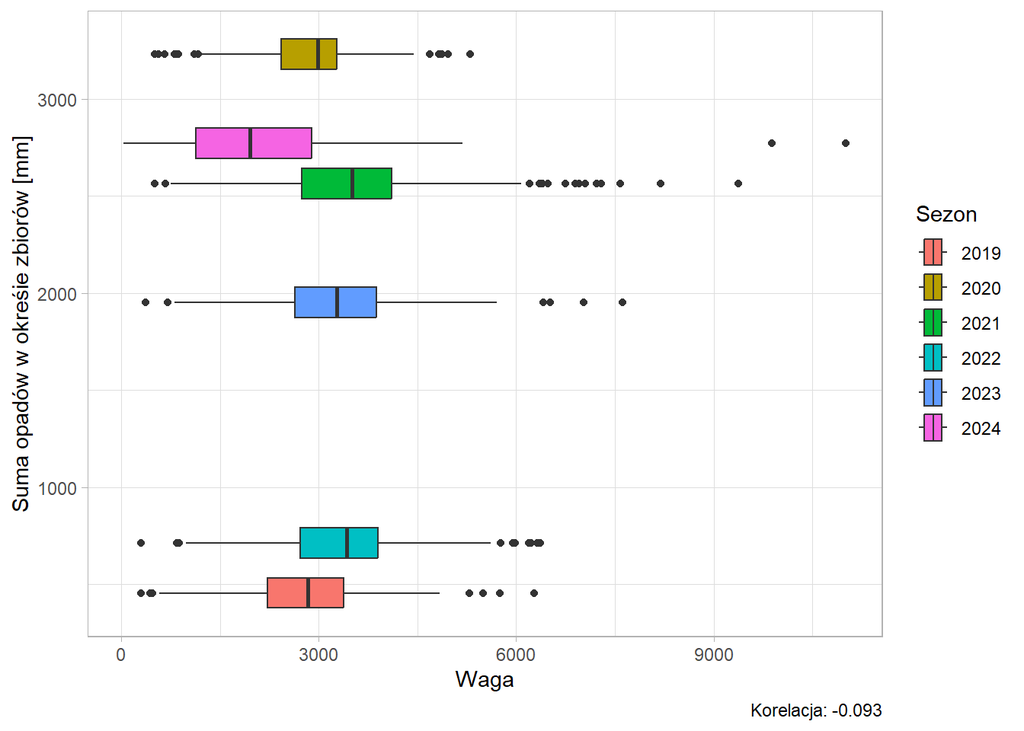

**Maksymalna dobowa suma opadów**

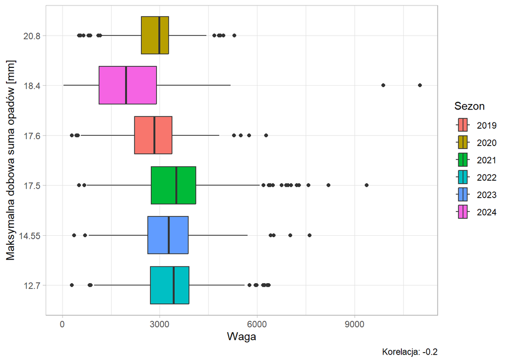

**Średnia suma opadów w dzień**

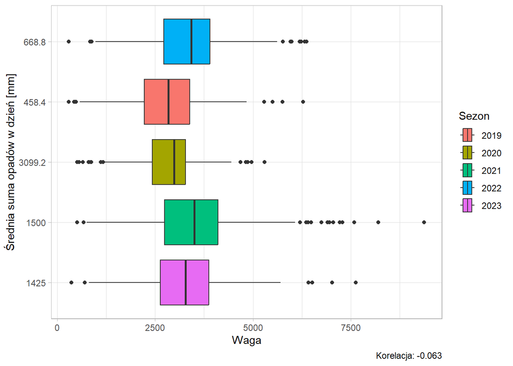

**Średnia suma opadów w noc**

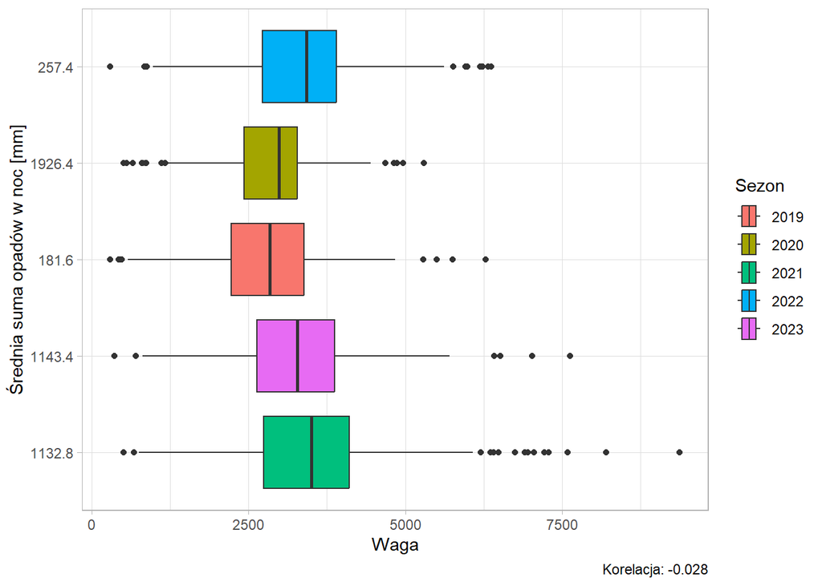

**Dni z deszczem**

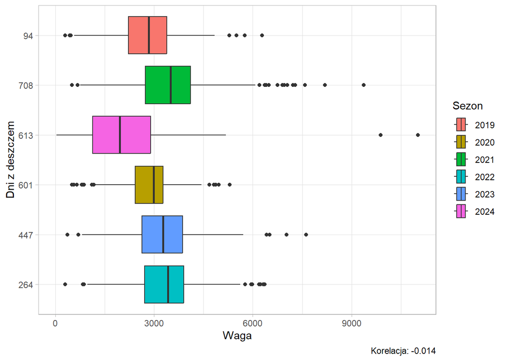

# Pytanie 2

“Jak sytuacja przy gruncie wpływa na jakość i ilość tymianku?”

## Odpowiedź na hipotezę 2.1

“Minimalna temperatura gruntu w miesiącach wzrostu tymianku ma wpływ na jego ilość w okresie zbiorów.”

[figure not shown]

Brak korelacji pomiędzy przyjętą wagą ziół a minimalną temperaturą gruntu.

## Odpowiedź na hipotezę 2.2

“Ilość dni z zaobserwowaną rosą w pierwszych miesiącach wzrostu tymianku ma wpływ na jego ilość w okresie zbiorów.”

[figure not shown]

Dziury w specyficznych danych pogodowych usuwają dwa sezony upraw z analizy, w tym co zostało nie widać istotnej korelacji.

# Pytanie 3

“Jak warunki atmosferyczne wpływają na jakość i ilość tymianku?”

## Odpowiedź na hipotezę 3.1

“Duże nasłonecznienie w miesiącach zbiorów tymianku pozytywnie wpływają na jego jakość.”

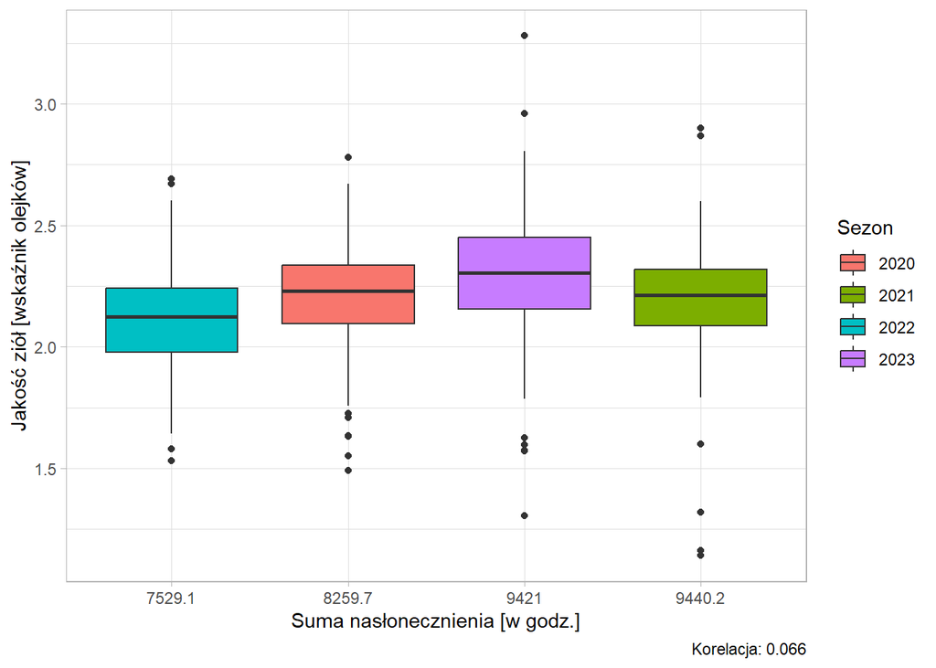

Brak korelacji pomiędzy nasłonecznieniem podczas zbiorów a jakością tymianku.

## Odpowiedź na hipotezę 3.2

“Duże nasłonecznienie w miesiącach siania tymianku negatywnie wpływają na jego ilość.”

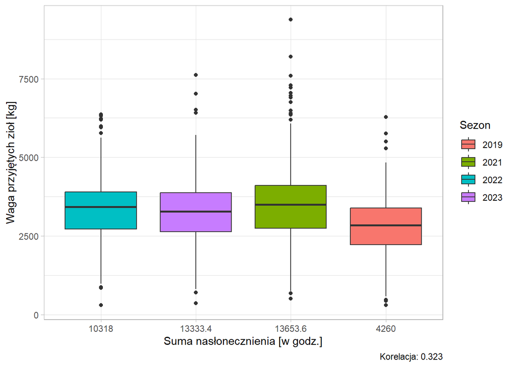

Nieduża korelacja pomiędzy nasłonecznieniem podczas siania a ilością tymianku.

## Odpowiedź na hipotezę 3.3

“Ciśnienie atmosferyczne nie wpływa znacznie na uprawy tymianku.”

**Korelacja w momencie przyjęcia**

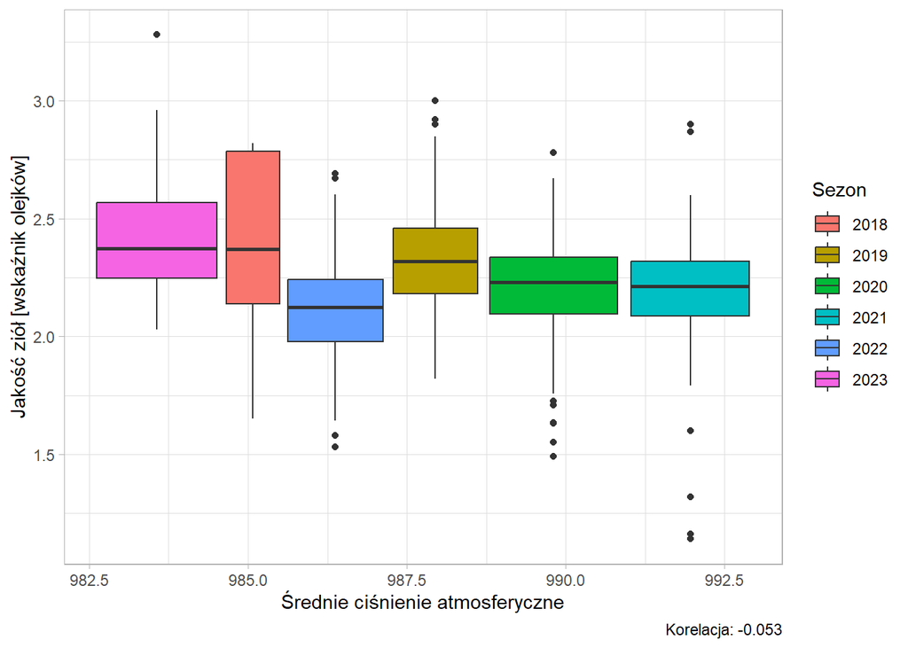

**Korelacja w momencie wzrostu**

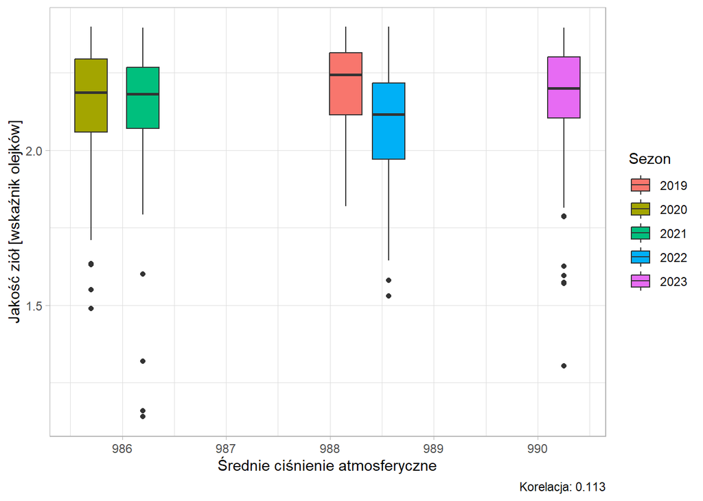

**Korelacja w momencie zbiorów**

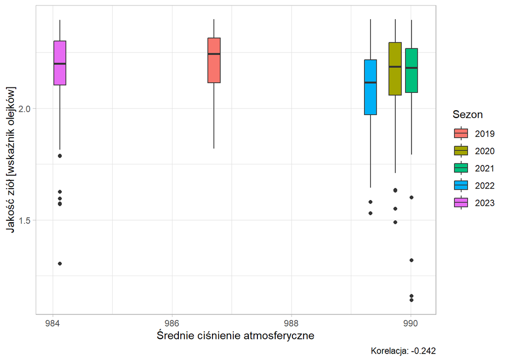

Nikła korelacja występuje tylko w momencie zbiorów

### Odpowiedź na hipotezę 3.4

“Prędkość wiatru nie wpływa znacznie na uprawy tymianku.”

**Korelacja w momencie przyjęcia**

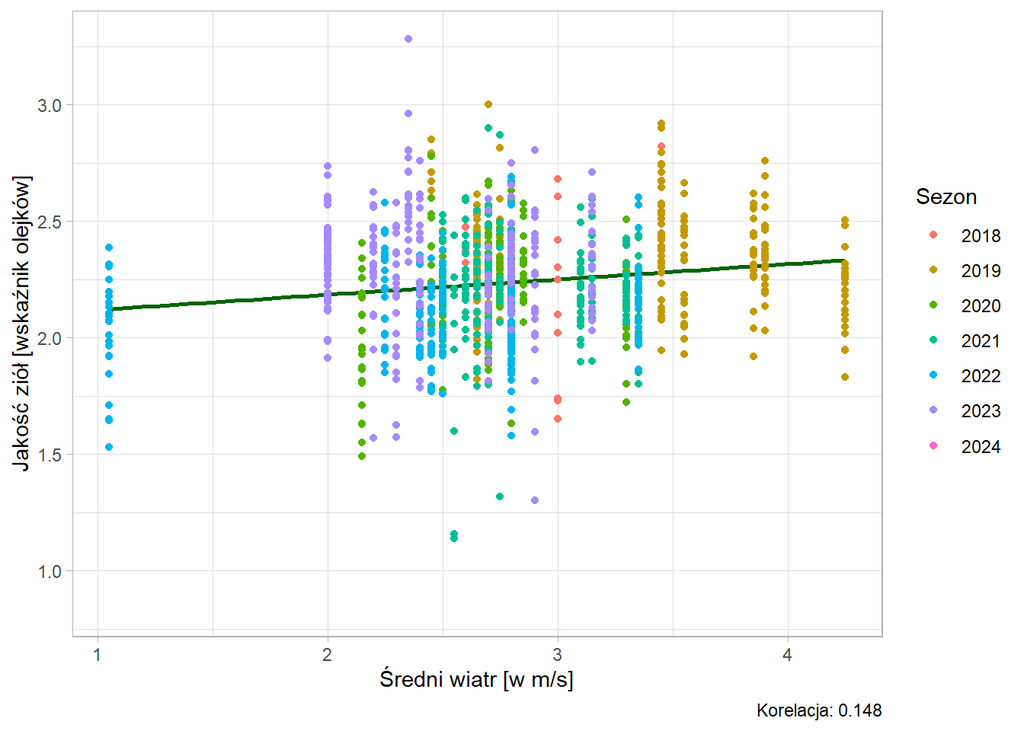

**Korelacja w momencie wzrostów**

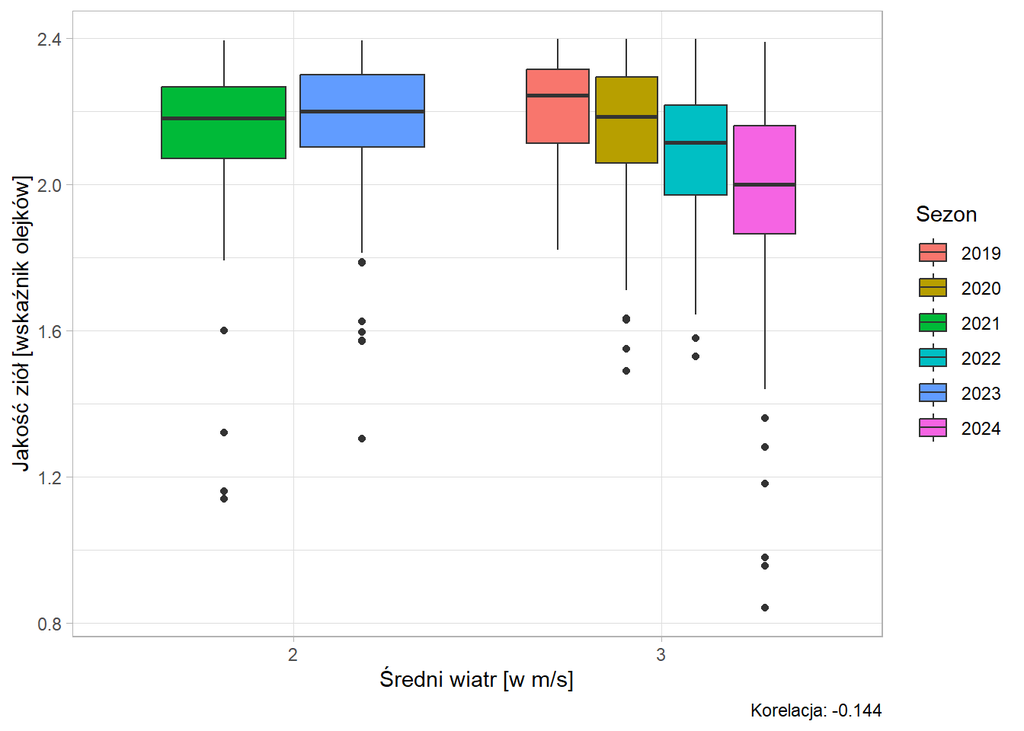

**Korelacja w momencie zbiorów**

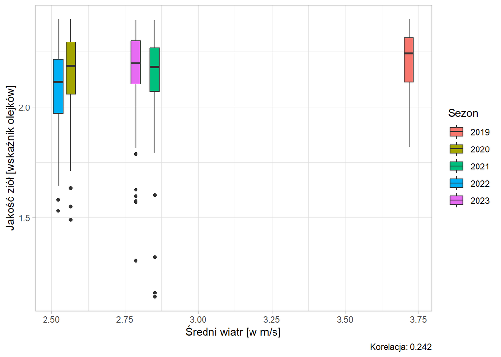

Nikłą korelacje widać ponownie w momencie zbiorów.

### Słabości analizy

Analiza jest okrojona bo nie znam testow statystycznych i metod progrostycznych. Brak korelacji w wielu miejscach, w których powinna się pojawić najprawdopodobniej jest spowodowany ogólnością posiadanych danych.

Część z hipotez zostały ułożone na podstawie obserwacji rolników. Brak jakiejkolwiek korelacji w tych wypadkach jest ewidentnym błędem analizy.

Jeżeli dane zawierałyby dokładny czas siania oraz zbiorów tymianku zamiast samych informacji o sezonie, oraz jeżeli dane pogodowe byłyby zbierane w skali dni zamiast miesięcy, z pewnością pojawiłoby się więcej korelacji.

# Podsumowanie

Jak zima wpływa na nadchodzący sezon?

Co ma największy wpływ na jakość?

[figure not shown]